# GoM cod and haddock RDM

Lou Carr-Harris

December 28th, 2023

This file is an exploratory analysis of the effect of climate-induced shifts in angler catch-per-trip of Gulf of Maine cod and haddock. Results are based on 100 iterations of the recreation demand model. The RDM is calibrated to 2020 fishery conditions.

### Baseline (2020) fishery statistics

Cod keep per choice occasion

```
   mean    sd
 0.0102 1e-04
```

Cod keep per trip

```
   mean    sd
 0.0156 2e-04
```

Haddock keep per choice occasion

```
   mean     sd
 2.0857 0.0104
```

Haddock keep per trip

```
   mean    sd
 3.1916 0.006
```

### Baseline welfare calculations

After calibrating the simulation model to 2020 fishery conditions, I re-ran the model under two closure scenarios: (a) bag limits for both cod and haddock set to zero, and (b) bag limits for cod only set to zero.  
$~$

#### Scenario (a): close both fisheries

CV per choice occasion

```
  mean   sd
 66.12 0.47
```

Aggregate CV

```
     mean       sd
 31611797 174899.7
```

Number of trips under closure

```
     mean     sd
 256794.8 544.59
```

Number of trips under baseline fishery

```
     mean   sd
 312755.2 0.89
```

Percent reduction in trips from baseline fishery

```
   mean   sd
 -17.89 0.17
```

#### Scenario (b): close cod only

CV per choice occasion

```
 mean   sd
 0.88 0.17
```

Aggregate CV

```
     mean       sd
 420214.5 81018.19
```

Number of trips under closure

```
     mean     sd
 312054.4 170.05
```

Number of trips under baseline fishery

```
     mean   sd
 312755.1 0.85
```

Percent reduction in trips from baseline fishery

```
  mean   sd
 -0.22 0.05
```

### Fishery outcomes under climate-induced changes in catch-per-trip

Each tab contains projected fishery outcomes based on input data from alternative copula models.

### Clayton (independent catch)

Cod and haddock keep per choice occasion:

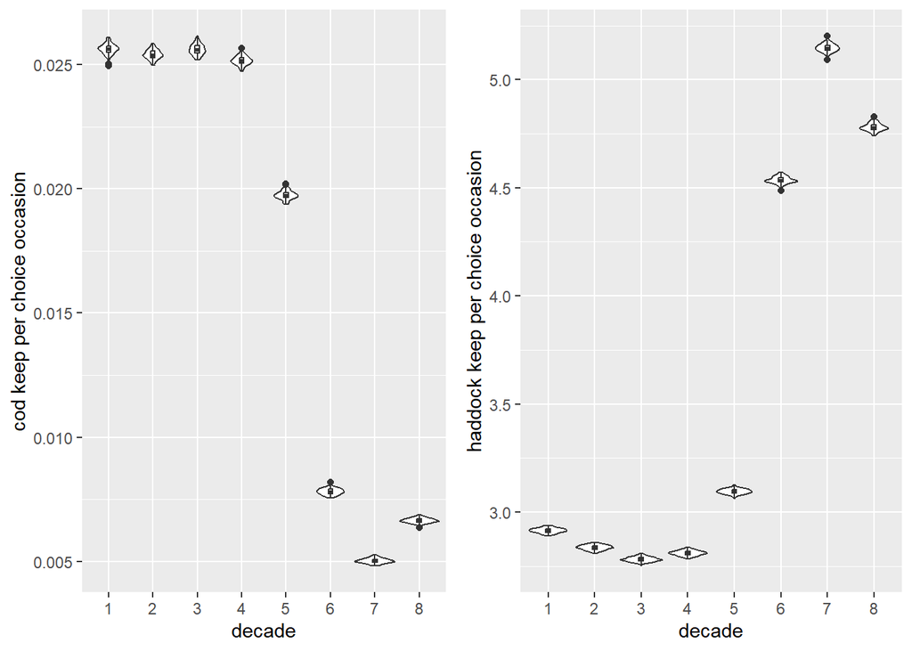

CV per choice occasion and number of trips:

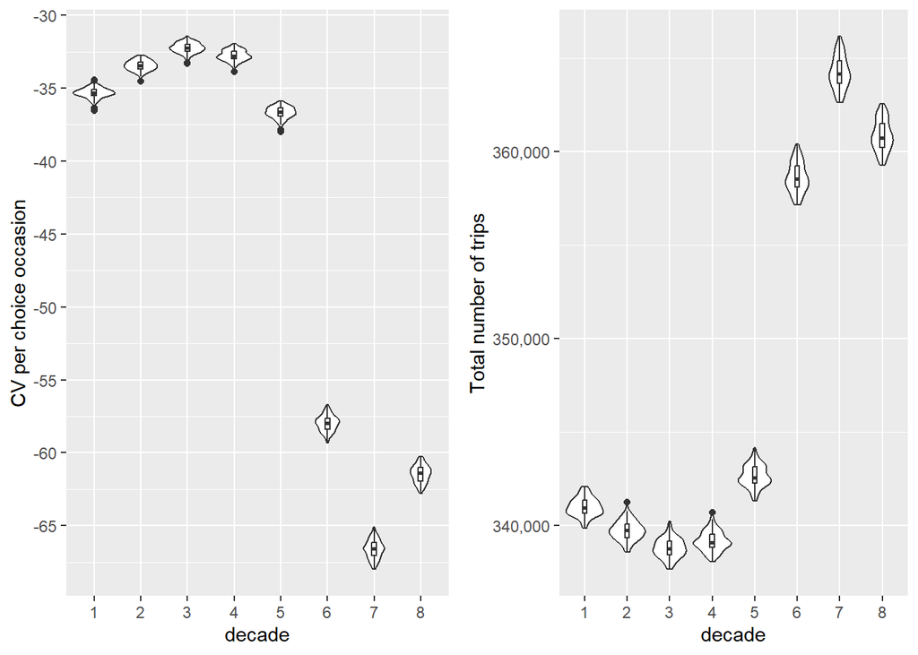

Correlation in catch and keep of cod and haddock per trip (kendall’s tau-b):

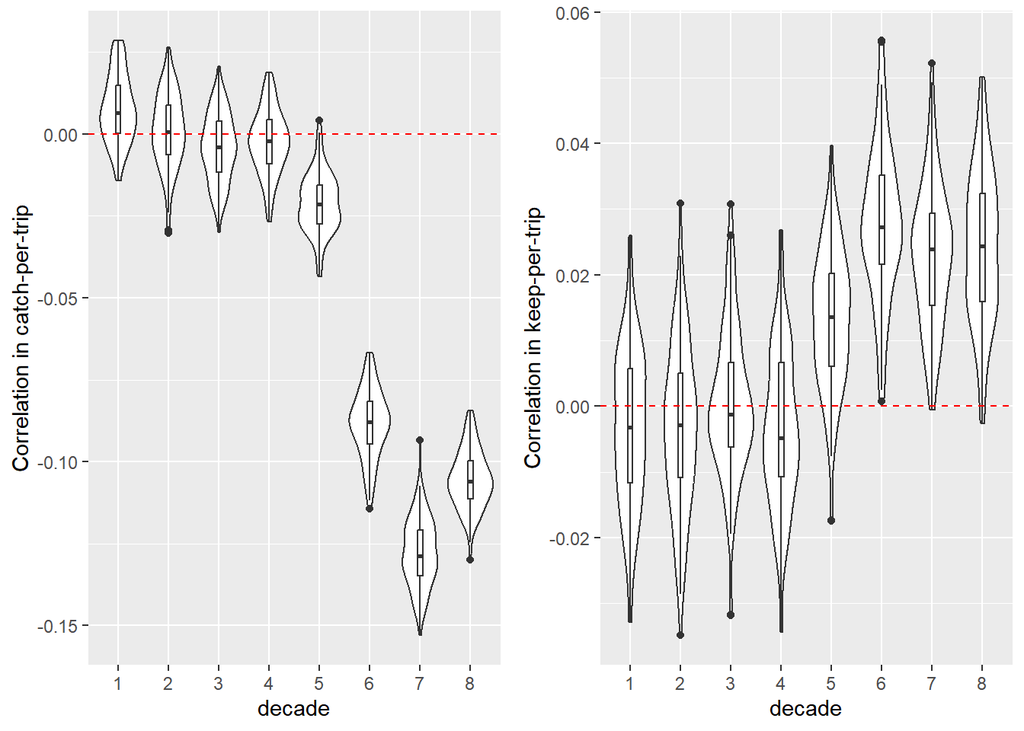

### Clayton (correlated catch)

Cod and haddock keep per choice occasion:

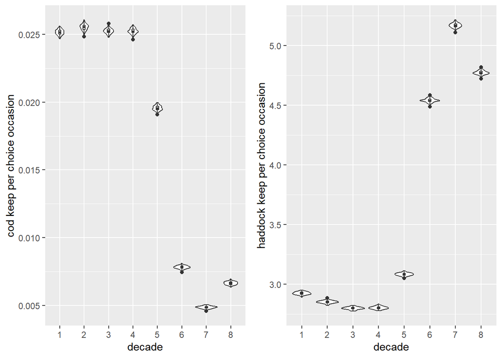

CV per choice occasion and number of trips:

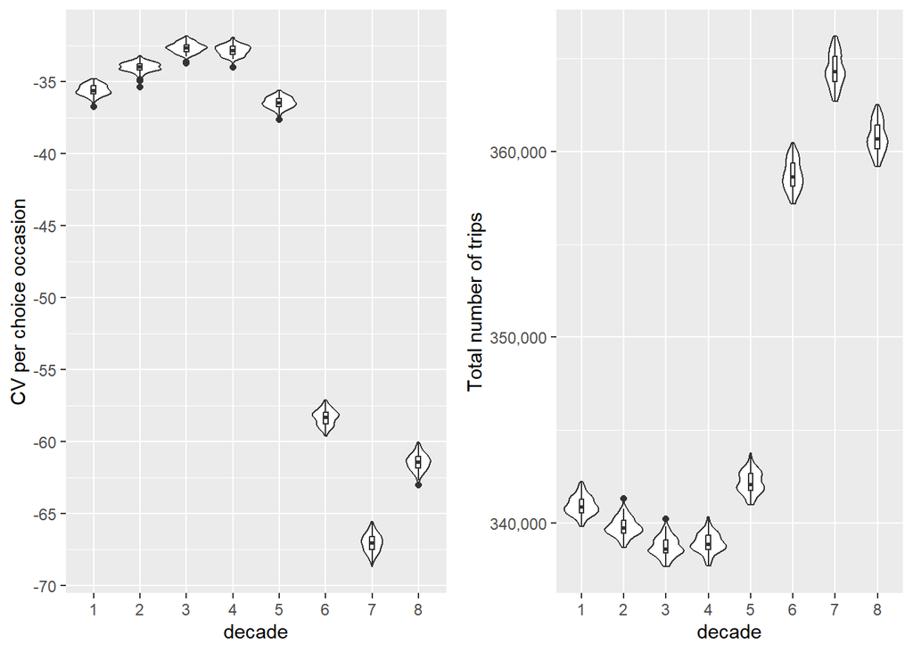

Correlation in catch and keep of cod and haddock per trip (kendall’s tau-b):

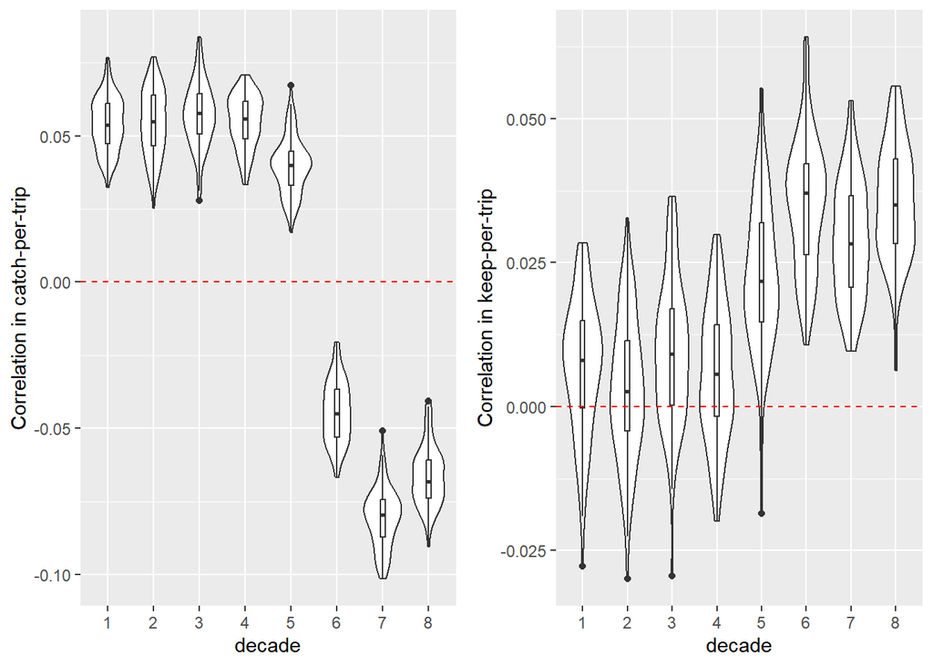

### Gumbel (independant catch)

Cod and haddock keep per choice occasion:

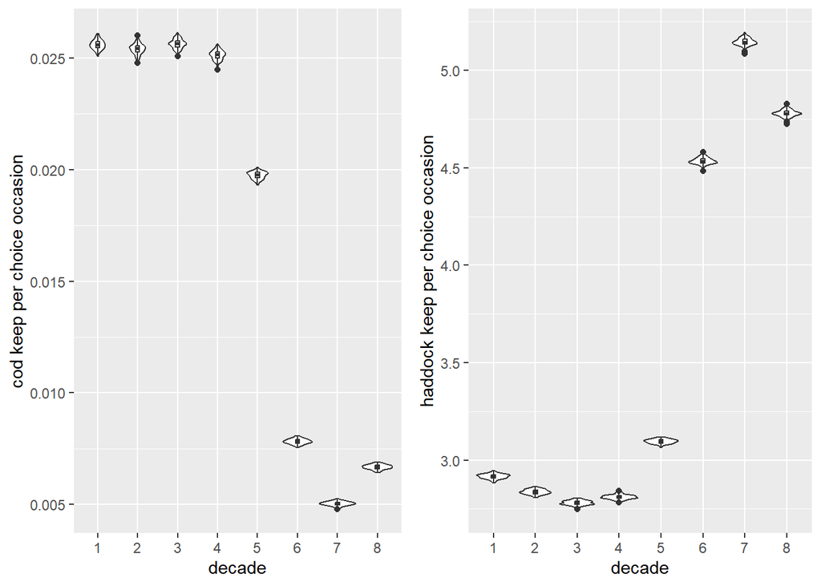

CV per choice occasion and number of trips:

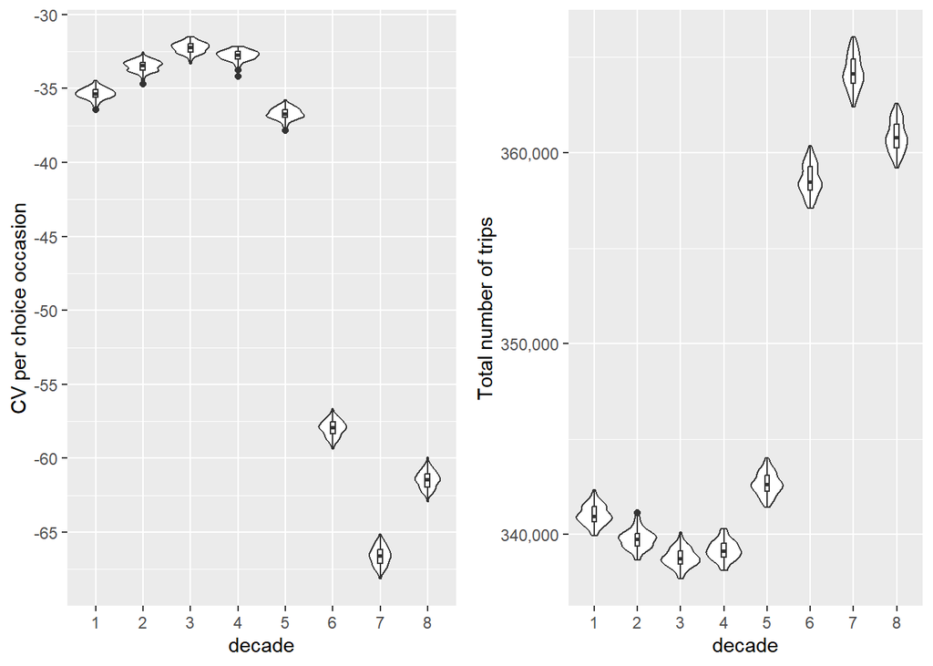

Correlation in catch and keep of cod and haddock per trip (kendall’s tau-b):

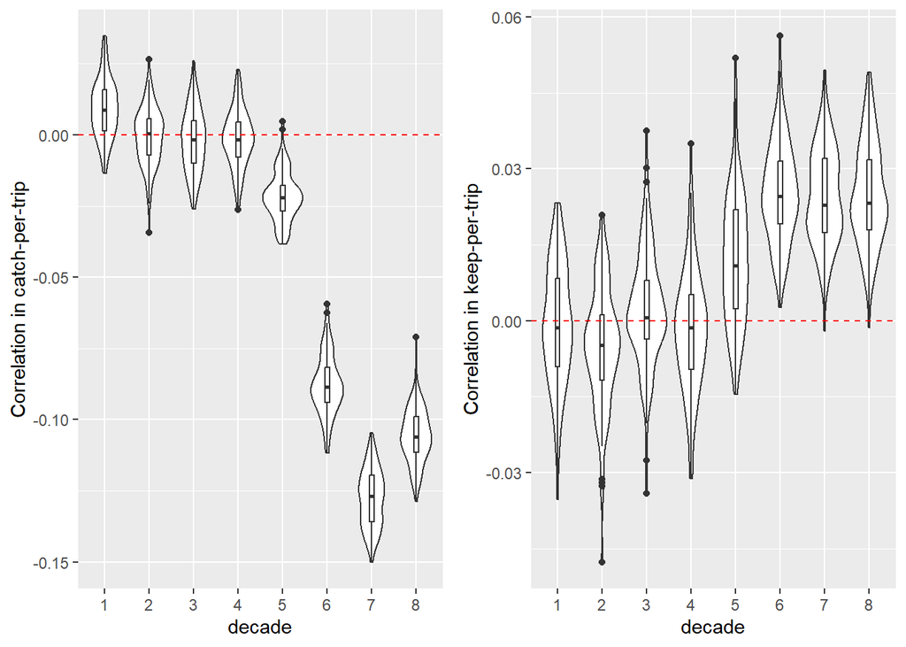

### Gumbel (correlated catch)

Cod and haddock keep per choice occasion:

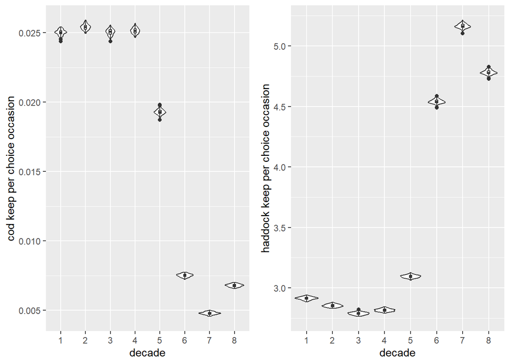

CV per choice occasion and number of trips:

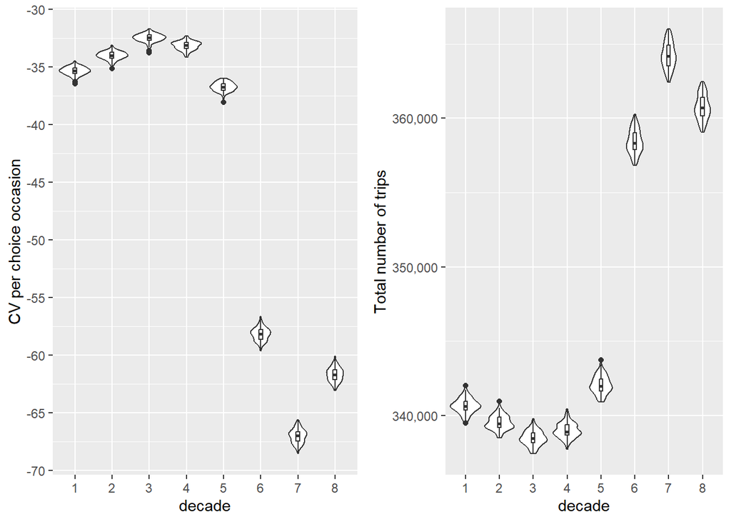

Correlation in catch and keep of cod and haddock per trip (kendall’s tau-b):

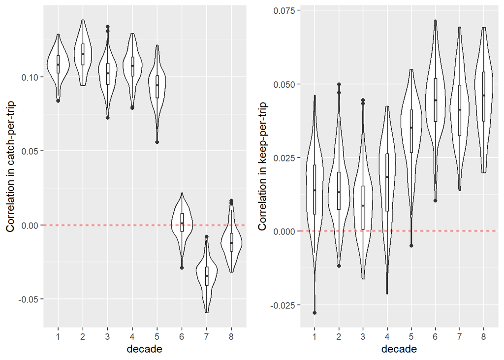

### Frank (independent catch)

Cod and haddock keep per choice occasion:

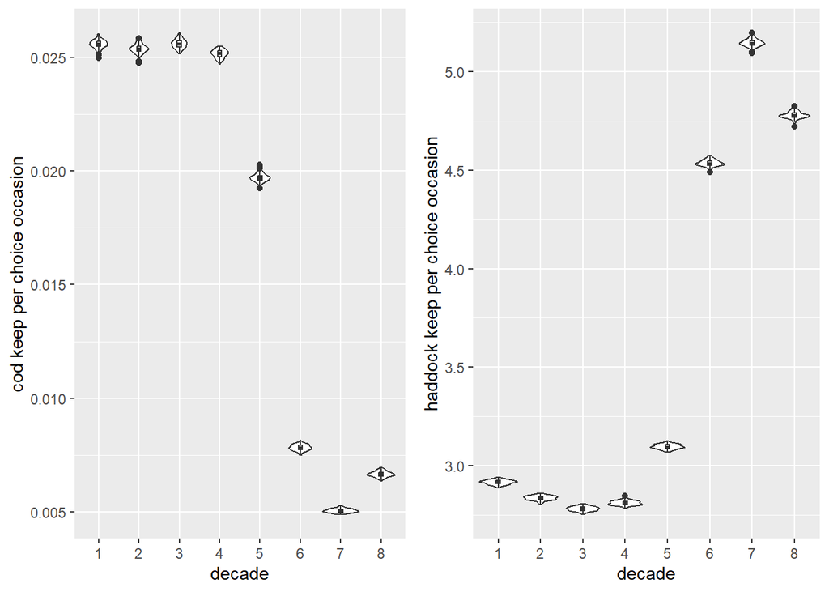

CV per choice occasion and number of trips:

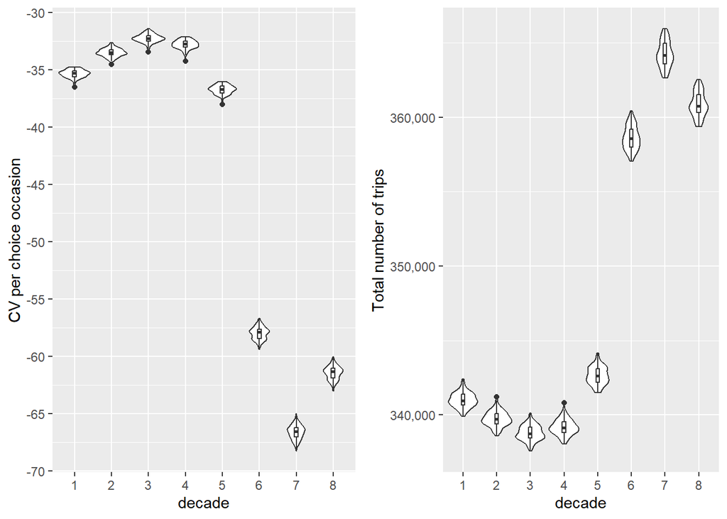

Correlation in catch and keep of cod and haddock per trip (kendall’s tau-b):

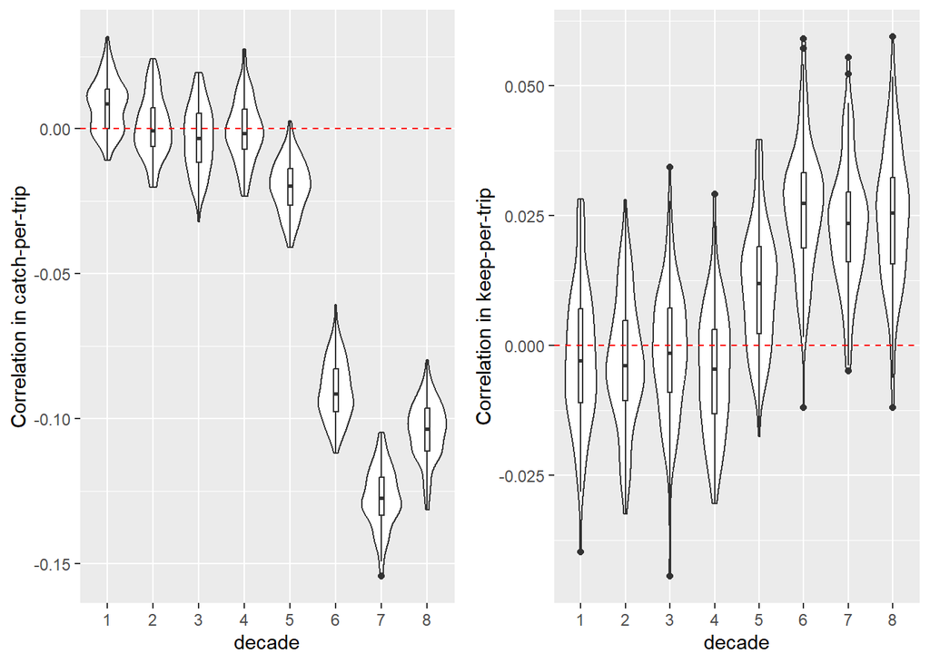

### Frank (correlated catch)

Cod and haddock keep per choice occasion:

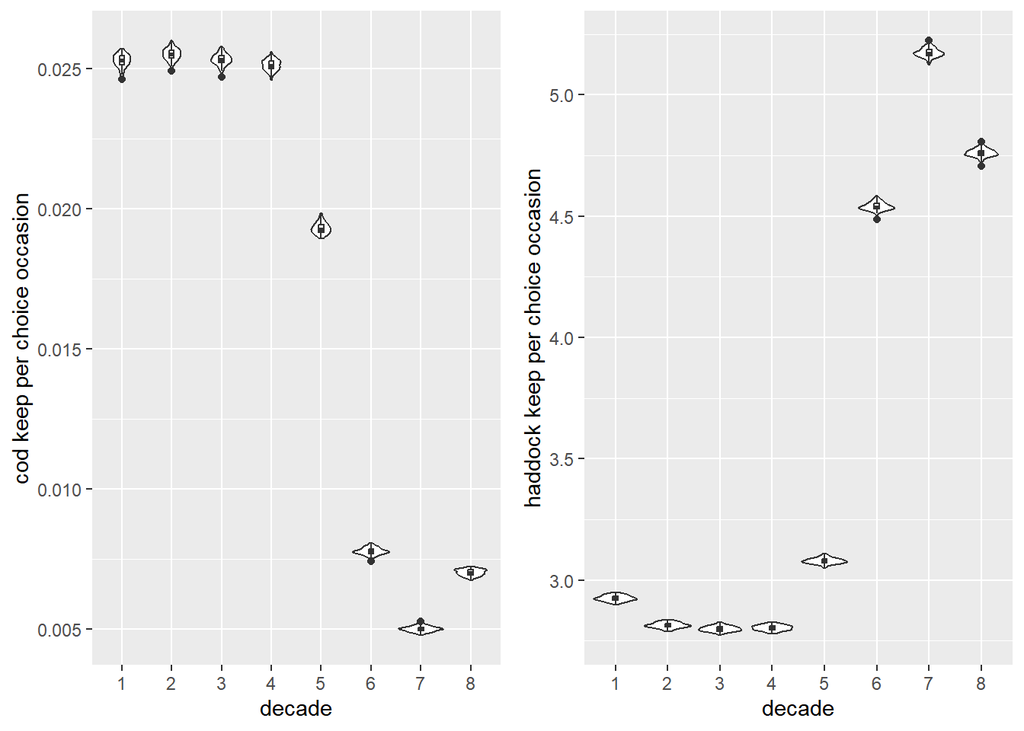

CV per choice occasion and number of trips:

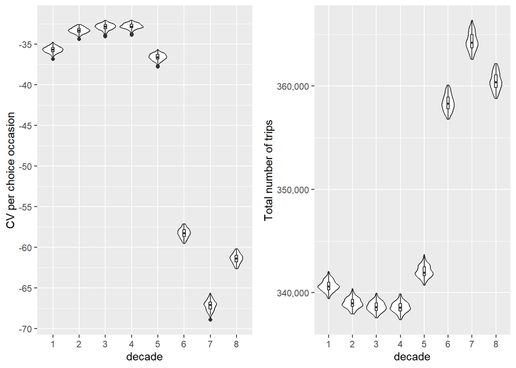

Correlation in catch and keep of cod and haddock per trip (kendall’s tau-b):

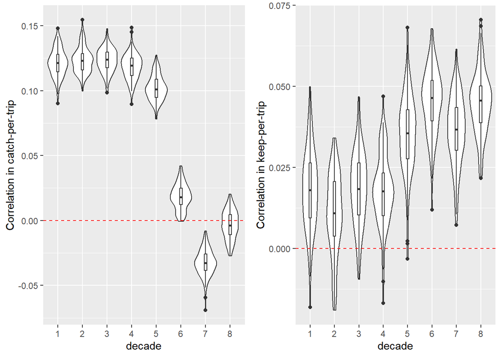

### All copulas (correlated catch, decade=1)

Cod and haddock keep per choice occasion:

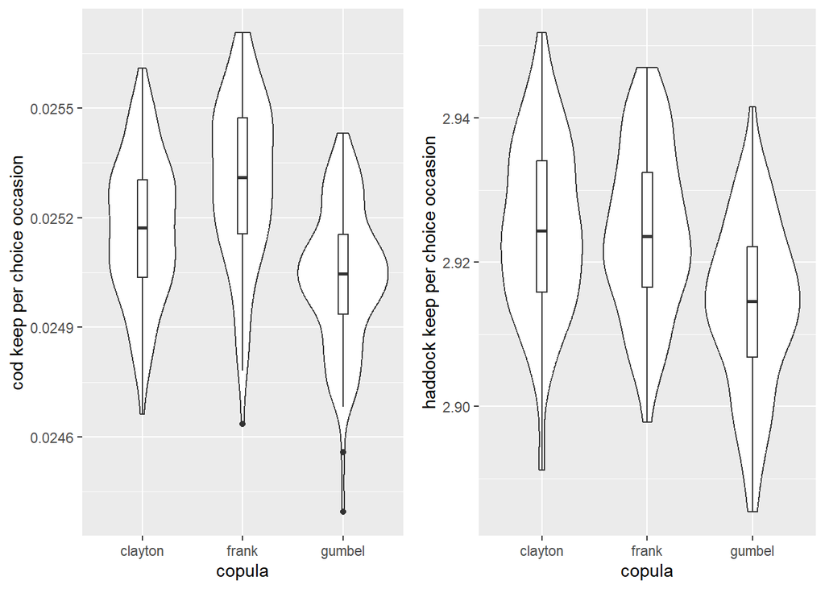

CV per choice occasion and number of trips:

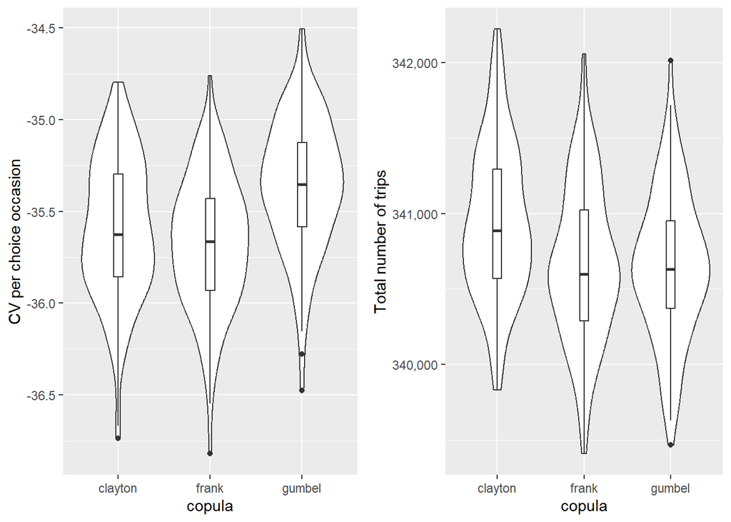

Correlation in catch and keep of cod and haddock per trip (kendall’s tau-b):

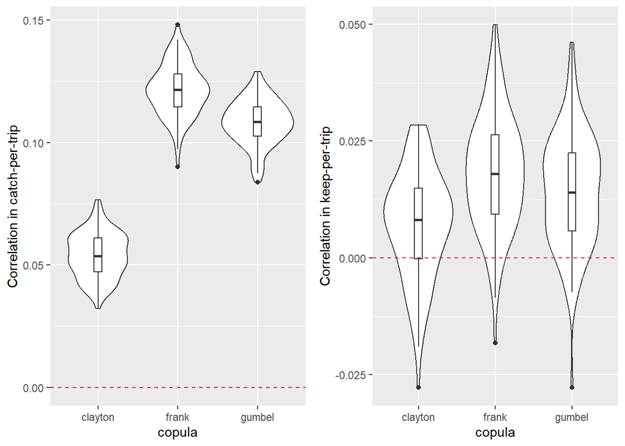

### All copulas (correlated catch, decade=4)

Cod and haddock keep per choice occasion:

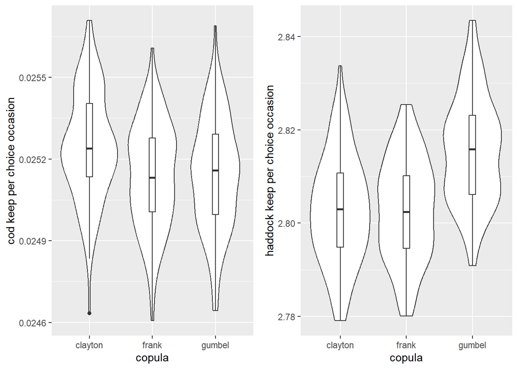

CV per choice occasion and number of trips:

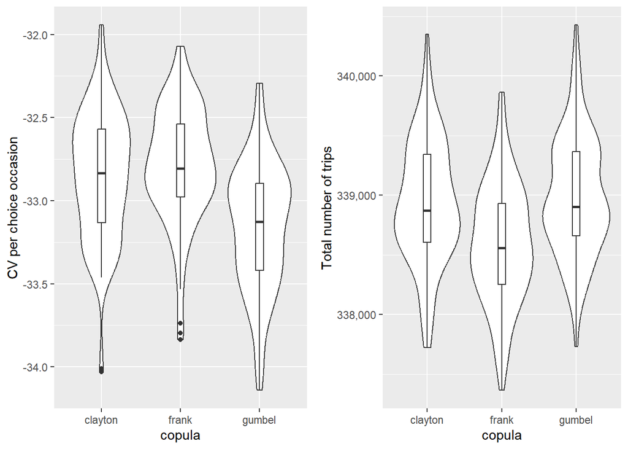

Correlation in catch and keep of cod and haddock per trip (kendall’s tau-b):

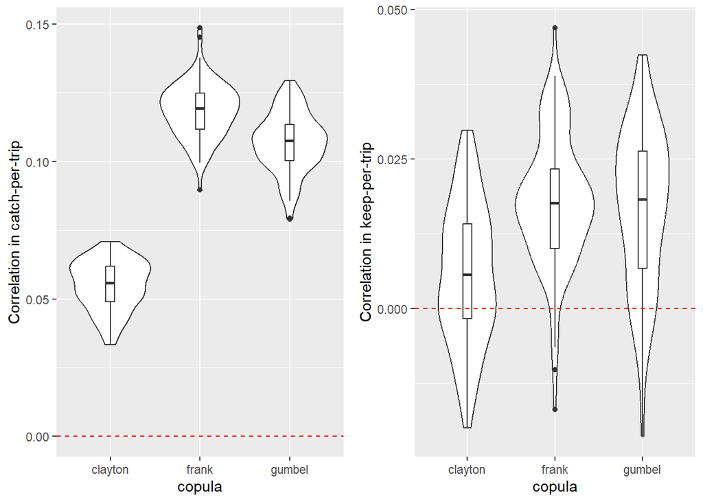

### All copulas (correlated catch, decade=8)

Cod and haddock keep per choice occasion:

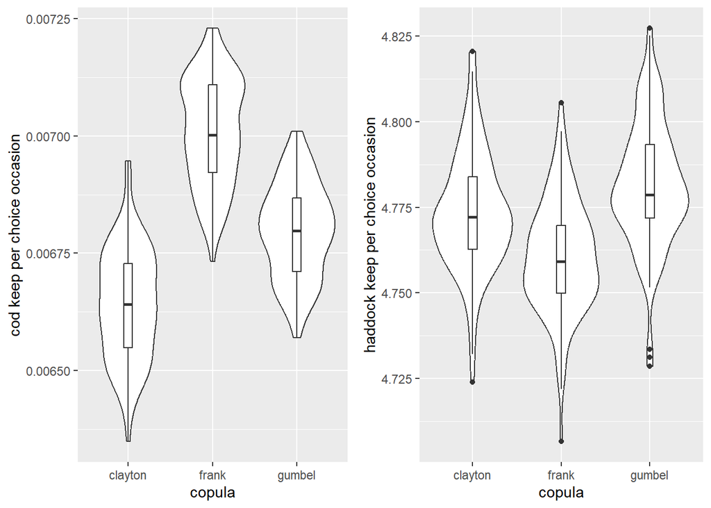

CV per choice occasion and number of trips:

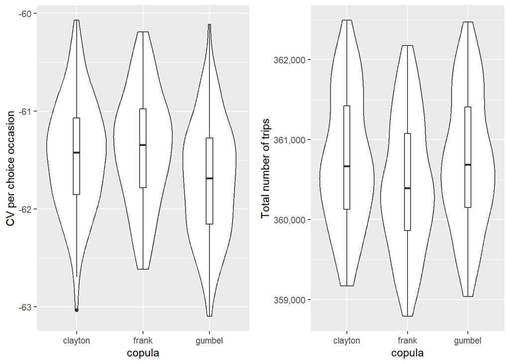

Correlation in catch and keep of cod and haddock per trip (kendall’s tau-b):

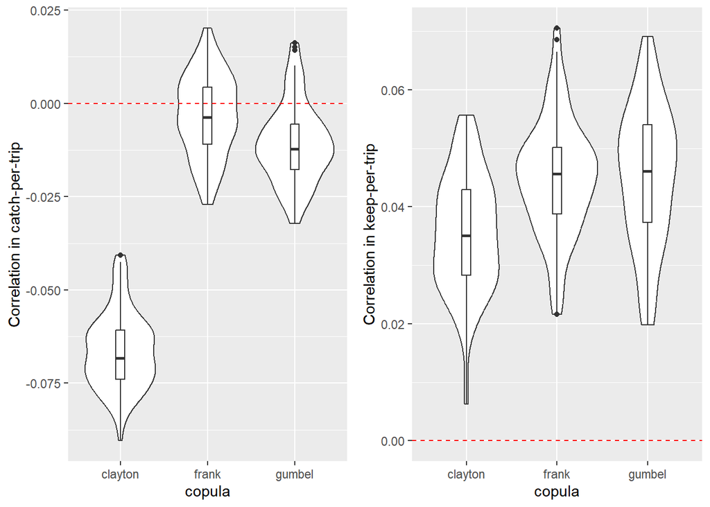

## {-}